# Data Structures

Di Cook, Heike Hofmann  
1/27/2014

### Outline

- Review of functions
- ldply and ddply

### Review: functions in R

Functions are objects in R (and have therefore to be defined using the assignment operator). They consist of a header and a body:

```r
is.currency <- function(x, currency = c("\\$", "€", "¥")) {
  x <- as.character(x)

  # check whether at least one of the elements in
  # vector currency is found:
  curr <- grep(paste(currency, collapse="|"), x)

  return (length(curr) > 0)
}

class(is.currency)
```

```
[1] "function"
```

Function to convert from currency to numeric format

```r
currency_to_numeric <- function(x, currency = c("\\$", "€", "¥")) {
  x <- as.character(x)
  x <- gsub(paste(currency, collapse="|"), "", x)
  x <- gsub(",", "", x)
  as.numeric(x)
}
```

### Apply both functions

```r
library(XML)
nba14 <- NULL
for (i in 1:15) {
  temp <- readHTMLTable(
    sprintf("http://espn.go.com/nba/salaries/_/page/%d",i))[[1]]
  nba14 <- rbind(nba14, temp)
}
nba14 <- subset(nba14, V1 != "RK")

# find currency information and get convert it to numbers:
for (i in 1:ncol(nba14)) {
  if (is.currency(nba14[,i]))
    nba14[,i] <- currency_to_numeric(nba14[,i])
}
head(nba14)
```

```
  V1                    V2                 V3       V4
2  1       Kobe Bryant, SG Los Angeles Lakers 30453805
3  2     Dirk Nowitzki, PF   Dallas Mavericks 22721381
4  3 Amar'e Stoudemire, PF    New York Knicks 21679893
5  4       Joe Johnson, SG      Brooklyn Nets 21466718
6  5   Carmelo Anthony, SF    New York Knicks 21388953
7  6      Dwight Howard, C    Houston Rockets 20513178
```

### What we should watch out for when programming

- *Vodoo Code* - code that you don’t quite understand, but that ‘has to be there’ so that everything works.
- *Yo-Yo Code* - multiple conversions between different representations (e.g. numeric to character and back) for simple operations.
- *Bulldozers* - code that looks it’s nicely structured (and general), but only works in one specific application.

Personal comment: I usually start with a concrete example (which makes any code a 'bulldozer'), but then try to generalize and apply my newly built functions to as many other examples as possible.

### Recursions

- Recursions are functions, that provide a part of the solution and then call themselves again.
- Recursions are a neat way of helping you out in more complicated situations.
- Once we have a solution in recursive form, we should get rid of the recursion …

Simple example: adding a vector of numbers

```r
rsum <- function(x) {
  if (length(x) == 1) return(x) # end of recursion

  return(x[1] + rsum(x[-1]))
}

rsum(c(1,3,5,7,9,11)) == sum(c(1,3,5,7,9,11))
```

```
[1] TRUE
```

### Recursions

- can easily be infinite
- by default R has a cap on the number of recursions

Evaluation of `rsum(1:1300)` gives the error message: `Error: evaluation nested too deeply: infinite recursion / options(expressions=)?`

- Parameter `expression` allows us to reset the number of recursions:

```r
options()$expressions
```

```
[1] 5000
```

```r
options(expressions=10000)
rsum(1:1300)
```

```
[1] 845650
```

### Recursions

- might cause the stack to overflow (there's a physical limit to the number of recursions on a computer), this causes a segmentation error and might lead to an ungraceful exit from R.
- are slow:

```r
system.time(rsum(1:900))
```

```
   user  system elapsed
  0.016   0.003   0.019
```

```r
system.time(sum(1:900))
```

```
   user  system elapsed
      0       0       0
```

- all recursions can be re-written in form of a loop

### Functions & plyr'ing

- small functions in the plyr functions ddply and ldply are a particularly powerful combination.
- Principle behind plyr: split, *apply* & combine
- Example: Identity function: `function(x) x` very useful when we want to convert a list to a data frame. Necessary conition: all list items must have the same number of elements

```r
names.list <- strsplit(as.character(nba14$V2), split=",")
library(plyr)
names.dframe <- ldply(names.list, function(x) x)
head(names.dframe)
```

```
                 V1  V2
1       Kobe Bryant  SG
2     Dirk Nowitzki  PF
3 Amar'e Stoudemire  PF
4       Joe Johnson  SG
5   Carmelo Anthony  SF
6     Dwight Howard   C
```

```r
nba14$name <- names.dframe$V1
nba14$pos <- names.dframe$V2
names(nba14)[c(3,4)] <- c("team", "salary")
```

### Summaries with ddply

- ddply requires data set as input, delivers data set as output

```r
ddply(nba14, .(pos), summarise,
      mean=mean(salary),
      sd=sd(salary),
      n=length(name))
```

```
  pos    mean      sd   n
1   C 4769074 5029339  98
2   F 1177594  455950   2
3   G  256990  306339   2
4  NA  596508  175725   5
5  PF 4098052 4609139 114
6  PG 3270867 4128812 107
7  SF 3682197 4582305 115
8  SG 3107857 4284076 126
```

- we should ignore positions F, G, and NA
- standard deviation of salaries are very high - usually higher than average salaries

### Transformations with ddply

- *summarise* aggregates the data for each level of the split variable (i.e. the output is usually shorter in length than the original)
- *transform* extends the existing data set by additional variables

```r
# ranks of salary by position
head(ddply(nba14, .(pos), transform,
           rank=rank(-salary)))[, -c(1,2)]
```

```
                team   salary          name pos rank
1    Houston Rockets 20513178 Dwight Howard   C    1
2 Los Angeles Lakers 19285850     Pau Gasol   C    2
3         Miami Heat 19067500    Chris Bosh   C    3
4  Memphis Grizzlies 14860523    Marc Gasol   C    4
5      Brooklyn Nets 14693906   Brook Lopez   C    5
6       Phoenix Suns 14487500  Emeka Okafor   C    6
```

### Calculations on subsets

Data: From the 2006 ASA Data expo challenge, http://stat-computing.org/dataexpo/2006/. The data are monthly measurements on a very coarse 24 by 24 grid covering Central America, from Jan 1995 to Dec 2000.

```r
nasa <- readRDS("../data/nasadata.rds")
head(nasa)
```

```
  time y x   lat   long       date cloudhigh cloudlow cloudmid ozone pressure surftemp
1    1 1 1 -21.2 -113.8 1995-01-01       0.5     31.0      2.0   260     1000    297.4
2    1 1 2 -21.2 -111.3 1995-01-01       1.5     31.5      2.5   260     1000    297.4
3    1 1 3 -21.2 -108.8 1995-01-01       1.5     32.5      3.5   260     1000    297.4
4    1 1 4 -21.2 -106.3 1995-01-01       1.0     39.0      4.0   258     1000    296.9
5    1 1 5 -21.2 -103.8 1995-01-01       0.5     48.0      4.5   258     1000    296.5
6    1 1 6 -21.2 -101.3 1995-01-01       0.0     50.0      2.5   258     1000    296.5
  temperature  id day month year
1       296.9 1-1   0     1 1995
2       296.5 2-1   0     1 1995
3       296.0 3-1   0     1 1995
4       296.5 4-1   0     1 1995
5       295.5 5-1   0     1 1995
6       295.0 6-1   0     1 1995
```

### NASA data

For each location (unique x and y) compute a linear model of ozone over time and months:

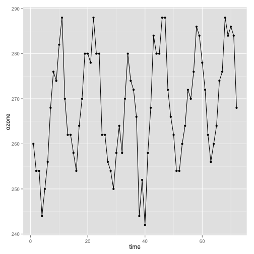

```r
library(ggplot2)
qplot(time, ozone, data=subset(nasa, (x==1) & (y==1))) + geom_line()
```

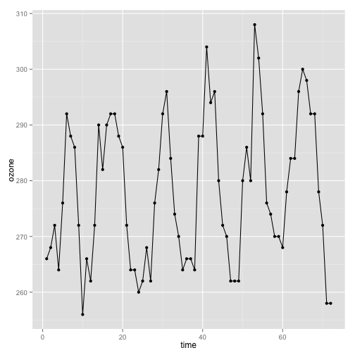

```r
library(ggplot2)
qplot(time, ozone, data=subset(nasa, (x==15) & (y==20))) + geom_line()
```

### List of models

```r
modlist <- dlply(nasa, .(x, y), function(x) { # x is now a subset of the original data
  m <- lm(ozone~time+factor(month), data= x)
  m
})
length(modlist)
```

```
[1] 576
```

```r
summary(modlist[[1]])
```

```
Call:
lm(formula = ozone ~ time + factor(month), data = x)

Residuals:
   Min     1Q Median     3Q    Max
-16.78  -2.65  -0.25   4.15   9.92

Coefficients:
                Estimate Std. Error t value Pr(>|t|)
(Intercept)     261.8250     2.6322   99.47  < 2e-16 ***
time              0.0917     0.0340    2.70  0.00909 **
factor(month)2   -7.0917     3.4116   -2.08  0.04200 *
factor(month)3   -9.8500     3.4121   -2.89  0.00543 **
factor(month)4  -13.6083     3.4130   -3.99  0.00019 ***
factor(month)5   -7.3667     3.4141   -2.16  0.03503 *
factor(month)6   -0.1250     3.4157   -0.04  0.97093
factor(month)7    8.7833     3.4175    2.57  0.01271 *
factor(month)8   10.0250     3.4197    2.93  0.00479 **
factor(month)9   11.6000     3.4222    3.39  0.00125 **
factor(month)10  19.5083     3.4251    5.70  4.1e-07 ***
factor(month)11  17.4167     3.4283    5.08  4.1e-06 ***
factor(month)12   7.6583     3.4318    2.23  0.02946 *
---
Signif. codes:  0 '***' 0.001 '**' 0.01 '*' 0.05 '.' 0.1 ' ' 1

Residual standard error: 5.91 on 59 degrees of freedom
Multiple R-squared:  0.807, Adjusted R-squared:  0.768
F-statistic: 20.6 on 12 and 59 DF,  p-value: <2e-16
```

### Extracting elements

Changes in ozone over time:

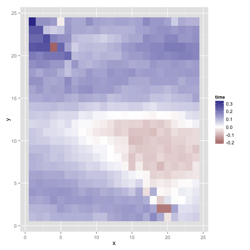

```r
modout <- ldply(modlist, function(x) coef(x)[2]) # now x is a list element, i.e. a model
qplot(x, y, fill=time, geom="tile", data=modout) + scale_fill_gradient2()
```

### Extracting elements

Largest residuals:

```r
resids <- ldply(modlist, function(x) {
  idx <- which.max(abs(resid(x)))
  c(resid(x)[idx], idx)
})
names(resids)[c(3,4)] <- c("resid", "time")
```

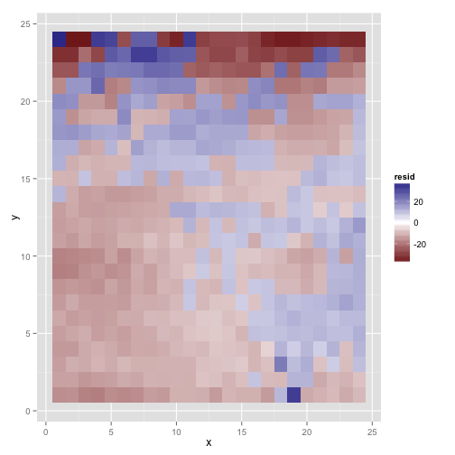

```r
qplot(x, y, fill=resid, geom="tile", data=resids) + scale_fill_gradient2()
```

### Extracting elements

When do large residuals occur?

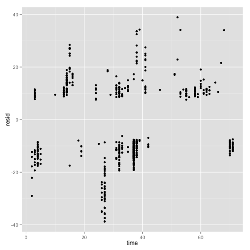

```r
qplot(time, resid, data=resids)
```